# An aging congress

Sam Johnson

2023-05-04

## Introduction

This analysis will use data from fivethirtyeight.com on the demographics of congressmen in the 118th congress of the United states. One of the problems often mentioned is that this congress is far too old. Here we will be looking at various metrics of age across the two chambers of Congress, as well as individually. These metrics will be party affiliation, location, and time in chamber and congress. Older members of Congress will be defined as 65 or older. The entirety of the code used to produce this report will be include at the end.

Before entering into the specific questions that we can ask, lets look at some of the summary statistics for Congress’ age.

```
##    Min. 1st Qu.  Median    Mean 3rd Qu.    Max.
##   26.00   49.00   59.00   58.56   68.00   90.00
```

# 1. Who are the oldest members of Congress?

It is unacceptable that anyone in their 90s should be running the country. Despite this, there is one, at least by rounded age, while the rest of the oldest members of Congress are all in their 80s. The names of these congressmen can be found below.

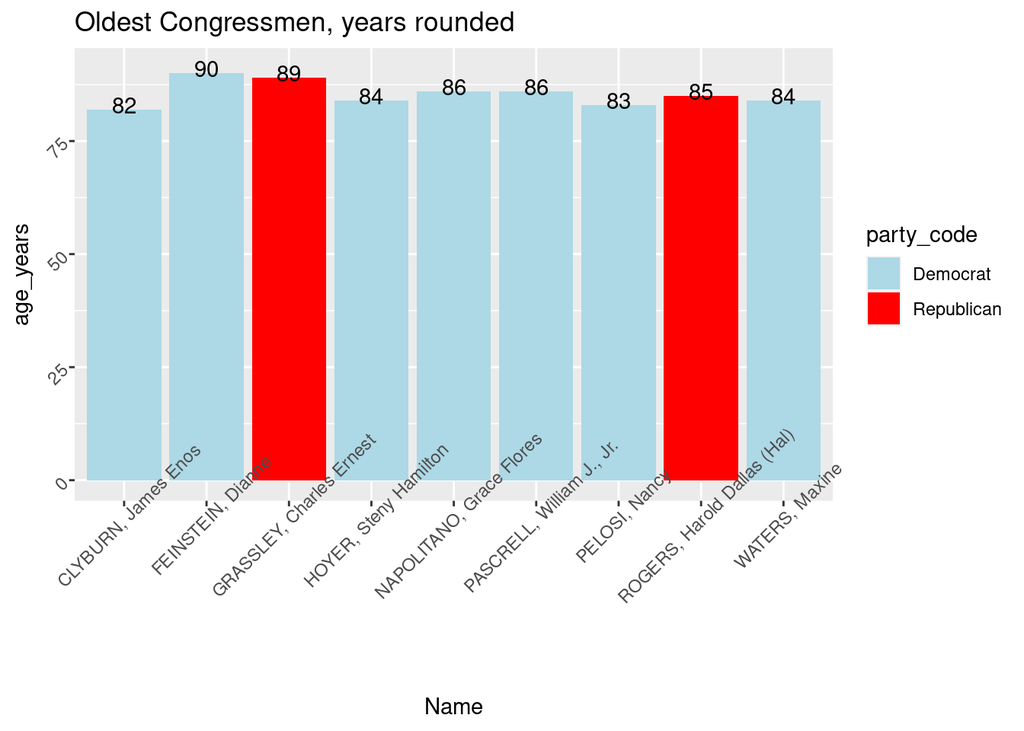

# 2. Which party dominates in terms of the oldest members of the Congress?

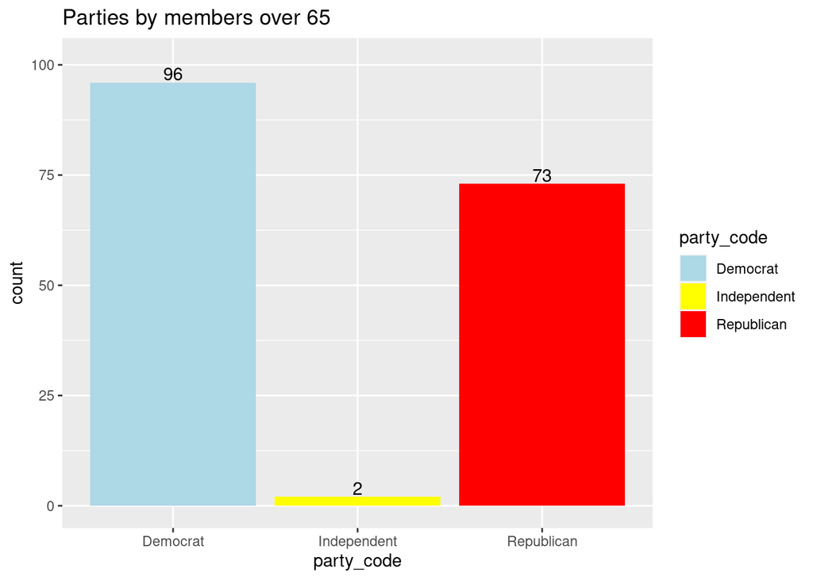

# 3. What is the distribution of congressmen across generations?

As expected, Baby boomers dominate the politics of the United States in 2023. However, Generation X is not that far behind. What truly is surprising is the number of Silent Generation members still around in Congress. It is surely safe to say that this generation’s positions will be filled with Gen Z and Millenials as the decade progresses.

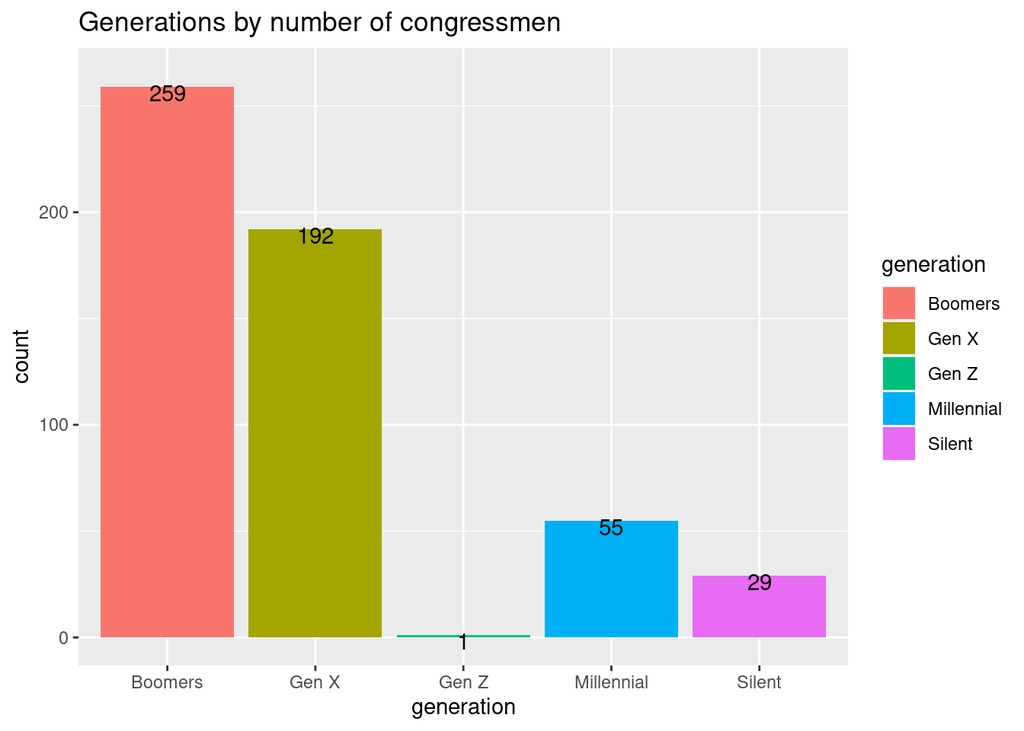

# 4. Which states have the most congressmen over 65?

Unsurprisingly, Californina and Texas, the most populous states, are also the worst offenders when it comes to having older people run the country. After these two giants, the number quickly declines with the rest of the top 10 having less than 10 older representatives. New Mexico is the only state that has no congressmen over 65.

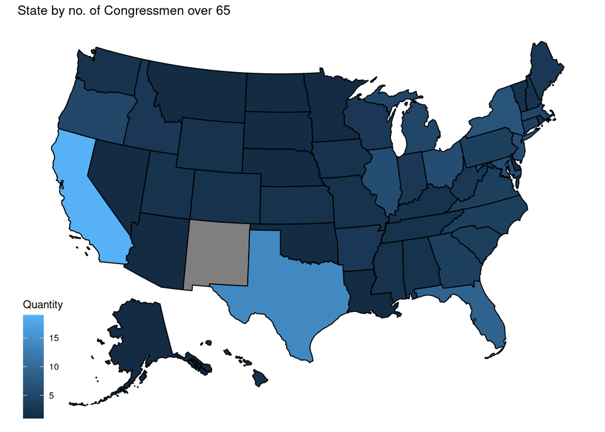

```
## # A tibble: 49 × 2
##    state          Quantity
##    <chr>             <int>
##  1 california           19
##  2 texas                14
##  3 florida               9
##  4 new york              7
##  5 illinois              6
##  6 maryland              6
##  7 new jersey            6
##  8 ohio                  6
##  9 massachusetts         5
## 10 michigan              5
## 11 oregon                5
## 12 connecticut           4
```

[output cut: 37 more lines]

# 5. Does the Senate or the House have more elderly?

Starting off with the House, we can see that only around 30% of its members are over 65. This does not seem like too much.

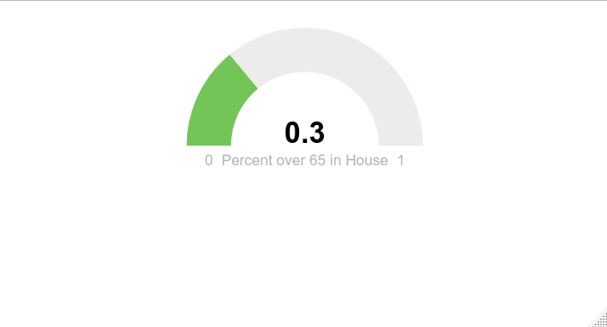

However, things are far more different for the Senate. 50% of the Senate is aged 65 or over! The Senate, is 20% older than the House!

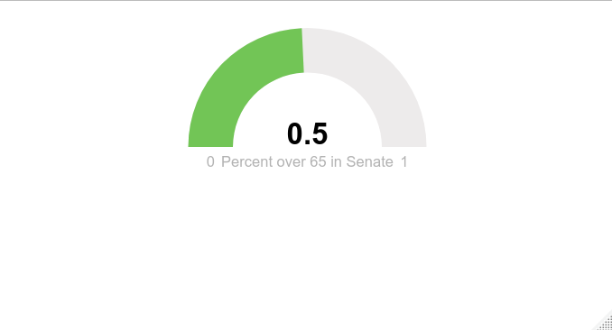

# 6. Which Congressmen have been in office for the longest?

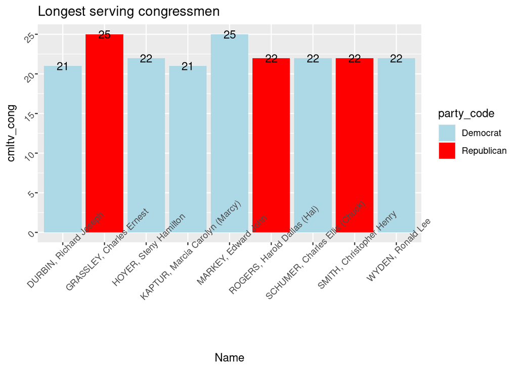

# 7. Which party is older in the Senate?

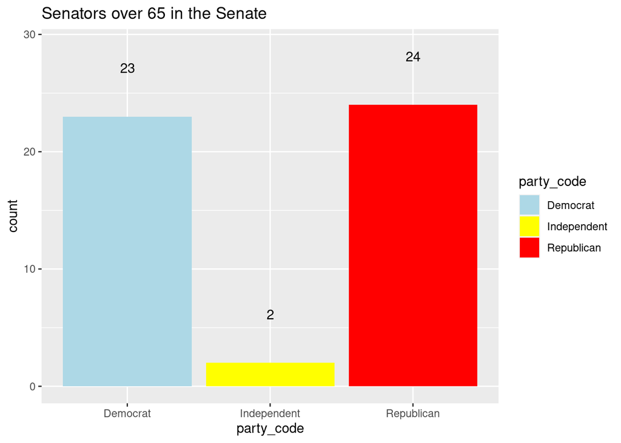

# 8. Which party is older in the House?

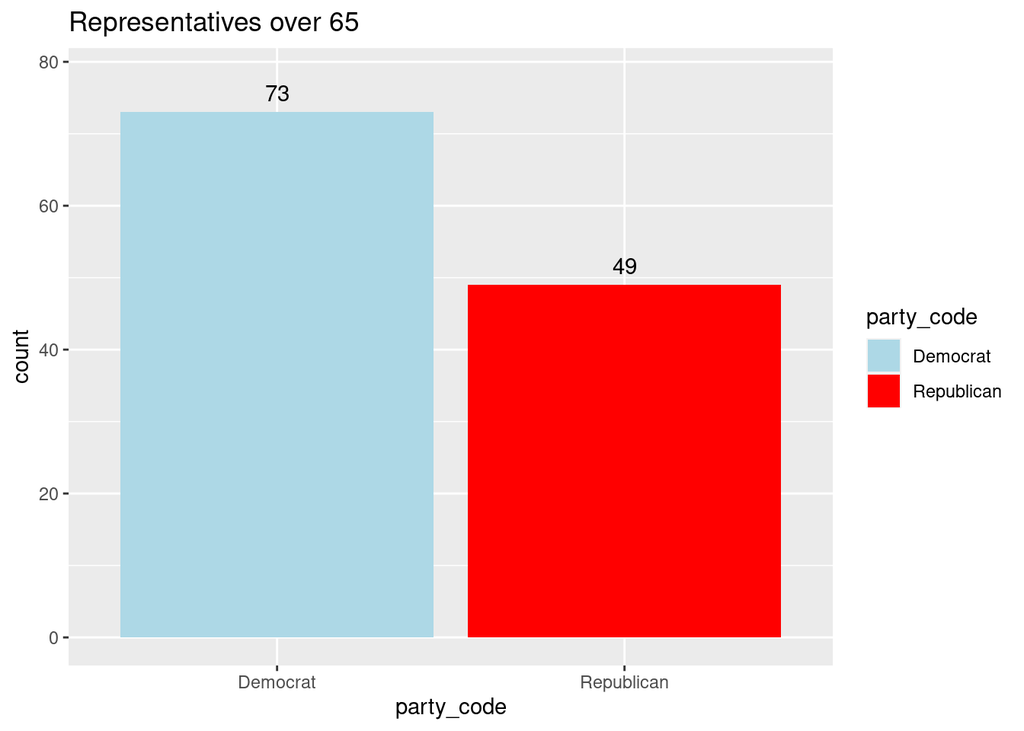

# Code used

```
#Data from fivethirtyeight.com
library(tidyverse)
library(usmap)
library(flexdashboard)
#Reading in the data
data <- read_csv("data_aging_congress.csv")
#Basic viewing
head(data)
colnames(data)
View(data)

#Isolating the current congress
geezers <- data %>%
  filter(congress == 118) %>%
  select(-congress)
#Making the party names readable
geezers$party_code[geezers$party_code == 328] <- "Independent"
geezers$party_code[geezers$party_code == 200] <- "Republican"
geezers$party_code[geezers$party_code == 100] <- "Democrat"

View(geezers)
#Who are the oldest congressmen
oldestGeezers <- geezers %>%
  arrange(desc(age_years)) %>%
  select(bioname, age_years, generation, party_code, chamber, state_abbrev, cmltv_cong, cmltv_chamber) %>%
  rename(Name = bioname) %>%
  rename(region = state_abbrev)
oldestGeezers$age_years <- round(oldestGeezers$age_years)
oldestGeezers$region <- state.name[sapply(oldestGeezers$region, \(x) which(x == state.abb)[1])]
oldestGeezers$region <- tolower(oldestGeezers$region)
#Graphing out who the oldest congressmen are
ancientGraph <- oldestGeezers %>%
  filter(age_years > 81) %>%
  ggplot(aes(Name, age_years, fill = party_code, label = age_years)) + geom_col() +
  scale_fill_manual(values = c("lightblue", "red")) +
  theme(axis.text = element_text(angle = 45)) + geom_text(nudge_y = 1) +
  ggtitle("Oldest Congressmen, years rounded")
ancientGraph

#Which party has the oldest congressmen
```

[output cut: 69 more lines]

```
  ggplot(aes(party_code, fill = party_code)) + geom_bar() +
  scale_fill_manual(values = c("lightblue", "yellow", "red")) +
  geom_text(aes(label = ..count..), stat = "count", vjust = 1.5, nudge_y = 5) +
  ggtitle("Senators over 65 in the Senate")
senParties

#Which party is older in the House
houseParties <- oldestGeezers %>%
  filter(chamber == "House") %>%
  filter(age_years > 65) %>%
  ggplot(aes(party_code, fill = party_code)) + geom_bar() +
  scale_fill_manual(values = c("lightblue", "red")) +
  geom_text(aes(label = ..count..), stat = "count", vjust = 1.5, nudge_y = 5) +
  ggtitle("Representatives over 65")
houseParties
```